**Assignment: Differential Expression Analysis for Bulk-RNA seq data**

1. Dwaipayan Math
2. Aanandita Sahu
3. Abhradeep Mandal
4. Riya Pal
5. Shreyasri Das Adhikary

**Part A: Dataset Selection**

**1. What is the NCBI GEO database?**

Ans:- The NCBI GEO (Gene Expression Omnibus) is a public database that stores and provides access to high-throughput gene expression and other functional genomics data submitted by researchers. It allows users to search, download, and analyze datasets from experiments like microarrays, RNA-seq, and ChIP-seq.

**2. What is the GEO Series ID (e.g., GSEXXXXX) of the dataset you chose?** Ans: - GSE264441 **3. Explain the experiment and the dataset and why did you choose it?**

Ans: - GSE264441 is a bulk RNA-seq dataset generated from mouse brain astrocytes. The experiment investigates how the depletion of CCR2+ macrophages affects the astrocyte transcriptome in the context of neuroinflammation. The dataset includes astrocytes isolated from mice treated with diphtheria toxin (DTX) to deplete CCR2+ macrophages (DTX group) and control-treated mice (Control group).

Why I chose this dataset:

It is a well-structured, bulk RNA-seq dataset suitable for DESeq2 analysis.

The experiment clearly compares two biological conditions (Control vs DTX), making it ideal for identifying differentially expressed genes (DEGs).

It has raw counts, which is essential for DESeq2.

It relates to neuroimmunology, a field of high biomedical relevance.

**4. What are the number of different groups in the dataset?**

Ans :- There are 2 groups in the dataset:

Control group: Astrocytes from mice with normal CCR2+ macrophage presence. DTX group: Astrocytes from mice in which CCR2+ macrophages were depleted using diphtheria toxin.

Each group has 3 biological replicates, totaling 6 samples.

**Part B: Loading dataset and DESeq2**

```r
# STEP 1: Load count matrix
count_data <- read.table("C:/Users/Dwaipayan/Downloads/GSE264441_raw_counts_CCR2DTR_AstroRNAseq.txt.gz",
                         header = TRUE,
                         sep = "\t",
                         row.names = 1)

# Check dimensions and column names
dim(count_data)
```

```
## [1] 35976     6
```

```r
colnames(count_data)
```

```
## [1] "X1A_CtrlCCR2_S1_001" "X2A_CtrlCCR2_S2_001" "X3A_CtrlCCR2_S3_001"
## [4] "X5A_DTXCCR2_S4_001"  "X6A_DTXCCR2_S5_001"  "X7A_DTXCCR2_S6_001"
```

```r
# Display first 10 rows and all columns
head(count_data, 10)
```

```
##              X1A_CtrlCCR2_S1_001 X2A_CtrlCCR2_S2_001 X3A_CtrlCCR2_S3_001
## Xkr4                         266                 193                 126
## Gm39585                       84                  98                  62
## Gm38717                        5                   0                  12
## Rp1                            2                   0                  14
## Sox17                          7                  14                   9
## LOC108167609                   0                   0                   0
## Gm39586                        0                   0                   0
## LOC108167610                   1                   0                   0
## Gm29874                        0                   0                   0
## Mrpl15                       752                 985                 649
##              X5A_DTXCCR2_S4_001 X6A_DTXCCR2_S5_001 X7A_DTXCCR2_S6_001
## Xkr4                        142                113                147
## Gm39585                      51                 34                 60
## Gm38717                      11                  0                  0
## Rp1                           5                  0                  0
## Sox17                         6                  1                  7
## LOC108167609                  1                  0                  0
## Gm39586                       0                  0                  0
## LOC108167610                  0                  0                  0
## Gm29874                       1                  0                  0
## Mrpl15                      780                646                623
```

```r
#Q.Make a data frame for any two different conditions and their replicates.Make sure to include control as one of the conditions if possible. Justify your choice of the condition.

# Sample names from count_data
samples <- colnames(count_data)

# Extracting condition from sample names using pattern
condition <- ifelse(grepl("CtrlCCR2", samples), "Control", "DTX")

# Creating data frame
metadata <- data.frame(row.names = samples,
                       condition = factor(condition))

# Viewing it
metadata
```

```
##                     condition
## X1A_CtrlCCR2_S1_001   Control
## X2A_CtrlCCR2_S2_001   Control
## X3A_CtrlCCR2_S3_001   Control
## X5A_DTXCCR2_S4_001        DTX
## X6A_DTXCCR2_S5_001        DTX
## X7A_DTXCCR2_S6_001        DTX
```

Justification:- I chose the two conditions Control and DTX because they represent the core comparison in the experiment: astrocytes from mice with normal immune status (Control) versus astrocytes from mice with CCR2+ macrophage depletion (DTX). This comparison directly addresses the study’s objective of understanding how immune cell presence influences astrocyte gene expression during neuroinflammation.

```r
#Q. Pre-process the dataset for DESeq2 analysis.
# Step 1: Install BiocManager (from CRAN)
# install.packages("BiocManager")

# Step 2: Use BiocManager to install DESeq2 and shrinkage package
BiocManager::install(c("DESeq2", "apeglm"))
# Step 3: Load the libraries
library(DESeq2)
library(apeglm)
# Load the DESeq2 package
library(DESeq2)

keep <- rowSums(count_data) >= 10
filtered_counts <- count_data[keep, ] #Filtered genes with low counts

#Create DESeq2 dataset object
dds <- DESeqDataSetFromMatrix(countData = count_data,
                              colData = metadata,
                              design = ~ condition)

# Check the object
dds
```

```
## class: DESeqDataSet
## dim: 35976 6
## metadata(1): version
## assays(1): counts
## rownames(35976): Xkr4 Gm39585 ... LOC102639451 LOC102639672
## rowData names(0):
## colnames(6): X1A_CtrlCCR2_S1_001 X2A_CtrlCCR2_S2_001 ...
##   X6A_DTXCCR2_S5_001 X7A_DTXCCR2_S6_001
## colData names(1): condition
```

```r
#Q. Run DESeq2 on pre-processed data and display the results.
# Run DESeq2 analysis
dds <- DESeq(dds)
# Get results (contrast between DTX vs. Control)
res <- results(dds, contrast = c("condition", "DTX", "Control"))

# View summary of results
summary(res)
```

```
##
## out of 25826 with nonzero total read count
## adjusted p-value < 0.1
## LFC > 0 (up)       : 20, 0.077%
## LFC < 0 (down)     : 4, 0.015%
## outliers [1]       : 12, 0.046%
## low counts [2]     : 5883, 23%
## (mean count < 1)
## [1] see 'cooksCutoff' argument of ?results
## [2] see 'independentFiltering' argument of ?results
```

```r
# View top differentially expressed genes
head(res[order(res$padj), ])
```

```
## log2 fold change (MLE): condition DTX vs Control
## Wald test p-value: condition DTX vs Control
## DataFrame with 6 rows and 6 columns
##          baseMean log2FoldChange     lfcSE      stat      pvalue        padj
##         <numeric>      <numeric> <numeric> <numeric>   <numeric>   <numeric>
## Ddx3y    1141.462        10.5401  0.676400  15.58262 9.55567e-55 1.90454e-50
## Xist     1511.938       -11.4991  0.871716 -13.19131 9.84551e-40 9.81154e-36
## Eif2s3y   360.419        11.0761  1.198768   9.23959 2.47446e-20 1.64395e-16
## Kdm5d     152.160        10.7946  1.210887   8.91461 4.89555e-19 2.43933e-15
## Uty       143.652        10.7109  1.207363   8.87133 7.22785e-19 2.88116e-15
## Uba1y      15.994         7.5450  1.316464   5.73126 9.96868e-09 3.31143e-05
```

Part C

```r
# Filter for significant genes (padj < 0.05)
significant_genes <- res[which(res$padj < 0.05), ]

# Count how many significant genes
n_significant_genes <- nrow(significant_genes)
n_significant_genes
```

```
## [1] 16
```

```r
# Filter out rows with NA in 'padj' and select genes with adjusted p-value < 0.05
sig_res <- res[!is.na(res$padj) & res$padj < 0.05, ]

# Sort results by log2FoldChange
sorted_res <- sig_res[order(sig_res$log2FoldChange), ]

# Top 5 upregulated genes (highest log2FoldChange)
top_upregulated <- head(sorted_res[sorted_res$log2FoldChange > 0, ], 5)

# Top 5 downregulated genes (lowest log2FoldChange)
top_downregulated <- head(sorted_res[sorted_res$log2FoldChange < 0, ], 5)

# View the results (log2FoldChange and padj for top upregulated and downregulated genes)
top_upregulated[, c("log2FoldChange", "padj")]
```

```
## log2 fold change (MLE): condition DTX vs Control
##
## DataFrame with 5 rows and 2 columns
##         log2FoldChange        padj
##              <numeric>   <numeric>
## Vsnl1         0.783627 0.001543997
## Gng3          0.832280 0.017402018
## Gabra1        1.112034 0.007467948
## Tmem130       1.233509 0.027355087
## C4b           1.445842 0.000669137
```

```r
top_downregulated[, c("log2FoldChange", "padj")]
```

```
## log2 fold change (MLE): condition DTX vs Control
##
## DataFrame with 3 rows and 2 columns
##        log2FoldChange        padj
##             <numeric>   <numeric>
## Xist       -11.499079 9.81154e-36
## Tsix        -7.215595 2.23125e-04
## Phlda1      -0.869701 2.12979e-02
```

1. Xist (X-inactive specific transcript): Xist is a long non-coding RNA that plays a critical role in X-chromosome inactivation in female mammals. It coats one of the two X chromosomes, triggering epigenetic silencing and ensuring dosage compensation between XX females and XY males. Its differential expression often reflects changes in sex chromosome regulation, developmental stage, or epigenetic control.

2. Tsix (antisense transcript of Xist): Tsix is the antisense regulator of Xist and acts to repress Xist expression. It is important during early embryonic development for ensuring that the correct X chromosome is inactivated in females. The Tsix/Xist regulatory pair ensures balanced gene expression from X chromosomes and is a key component of X-chromosome counting and choice.

3. Phlda1 (Pleckstrin Homology-Like Domain, Family A, Member 1): Phlda1 is a protein-coding gene involved in cell survival, apoptosis regulation, and stress response. It is thought to play a protective role in neuronal injury and immune response pathways. Its upregulation or downregulation can indicate cellular stress adaptation or injury response, which might be relevant in the DTX-treated (immune cell-depleted) condition in your dataset.

```r
# Run PCA on the count data
vsd <- vst(dds, blind = FALSE)  # Variance Stabilizing Transformation for better visualization
pca_data <- plotPCA(vsd, intgroup = "condition", returnData = TRUE)
```

```
## using ntop=500 top features by variance
```

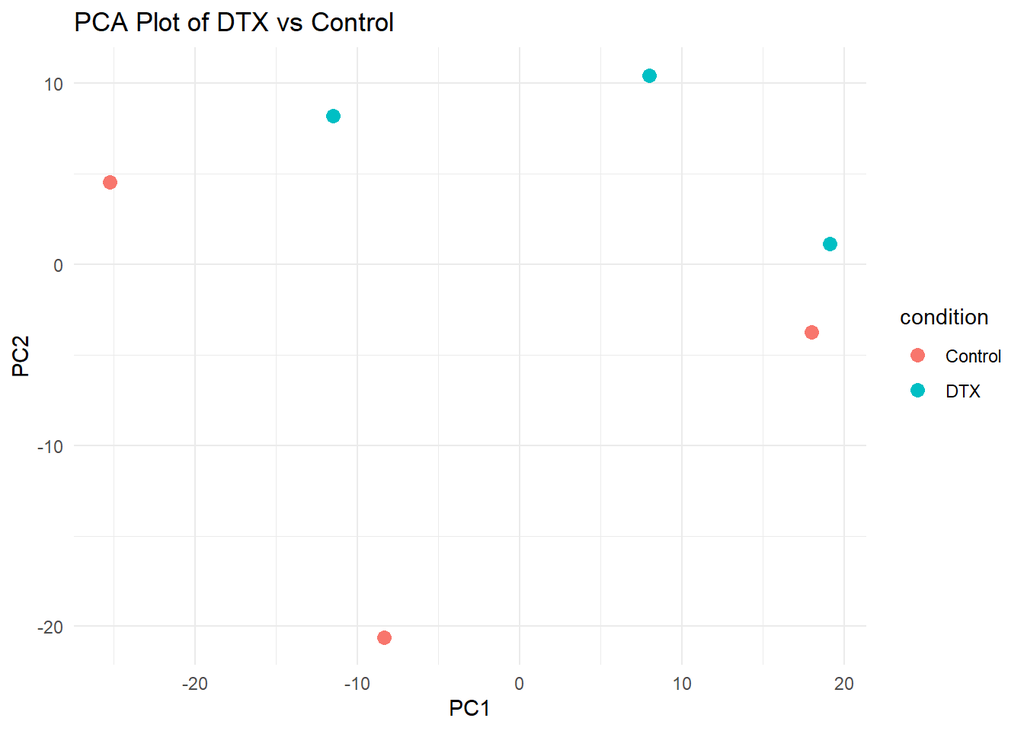

```r
# Plot PCA
library(ggplot2)
ggplot(pca_data, aes(x = PC1, y = PC2, color = condition)) +
  geom_point(size = 3) +
  labs(title = "PCA Plot of DTX vs Control", x = "PC1", y = "PC2") +
  theme_minimal()
```

```r
# Ensure that 'res' contains padj (adjusted p-values)
res$padj <- p.adjust(res$pvalue, method = "BH")  # Apply Benjamini-Hochberg adjustment if it's not already present
```

```r
# Prepare the volcano data frame with necessary columns
volcano_data <- as.data.frame(res)
volcano_data$gene <- rownames(volcano_data)

# Ensure it has the required columns
```

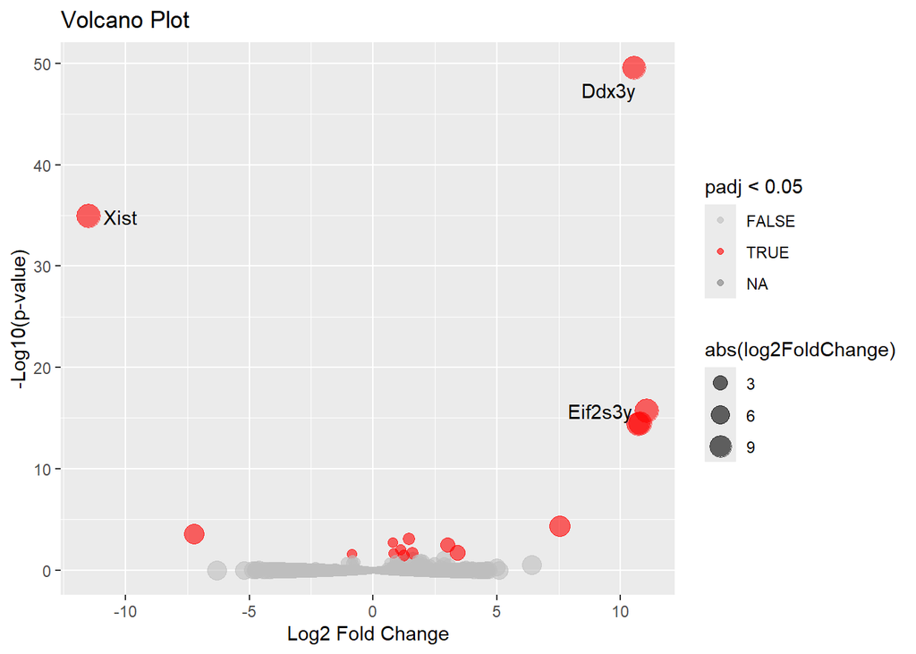

```r
library(ggplot2)
library(ggrepel)

# Create the volcano plot
volcano_plot <- ggplot(volcano_data, aes(x = log2FoldChange, y = -log10(padj), label = gene)) +
  geom_point(aes(color = padj < 0.05, size = abs(log2FoldChange)), alpha = 0.6) +
  scale_color_manual(values = c("gray", "red")) +
  geom_text_repel(data = volcano_data[volcano_data$gene %in% c("Ddx3y", "Xist", "Eif2s3y"), ],
                  aes(label = gene),
                  box.padding = 0.5,
                  point.padding = 0.5,
                  segment.color = "gray") +
  labs(x = "Log2 Fold Change", y = "-Log10(p-value)", title = "Volcano Plot")

# Display the volcano plot
print(volcano_plot)
```

A volcano plot visually identifies upregulated and downregulated genes in one plot, making it easier to spot the most important genes in your dataset.

**Part D:Interpretation**

**Q1.What challenges or issues did you encounter during the analysis?** Ans:- Here are some common challenges we faced during RNA-seq analysis using DESeq2-:

1.Data Quality Issues: Sometimes, the data had low-quality reads, or certain genes had very low counts, leading to difficulties in interpretation.

2.Memory/Computational Limits: Large datasets required substantial computational resources, and running DESeq2 on such data sometimes caused memory issues.

Solution: Efficient data processing and using batch processing for large datasets.

3.Metadata Mismatch: Ensuring that the metadata (e.g., experimental conditions) aligns perfectly with the count data (samples) is crucial.

Solution: Careful alignment of metadata columns with count data.

4.Complexity of Statistical Models: Understanding and properly interpreting results from statistical models like DESeq2 was challenging for us being new to RNA-seq data analysis.

Solution: Thorough understanding of the model assumptions and using appropriate filtering techniques. 5. Finding right dataset with raw counts was difficult.

**Q2.What assumptions does DESeq2 make about RNA-seq count data?** Ans:-DESeq2 makes several important assumptions about RNA-seq data:

1.Count Data is Poisson Distributed: DESeq2 assumes that the counts for each gene follow a negative binomial distribution (a generalization of the Poisson distribution that accounts for overdispersion), which is suitable for RNA-seq data where variance exceeds the mean.

2.Independence of Samples: DESeq2 assumes that the samples are independent of each other. This means there should not be any hidden structure (e.g., batch effects) unless specifically included in the model.

3.Size Factor Normalization: DESeq2 normalizes count data based on the library size of each sample. The assumption here is that most genes are not differentially expressed and can be used to estimate size factors (i.e., scaling factors for each sample).

4.Differential Expression is Not Dependent on Other Factors: DESeq2 assumes that differential expression results are primarily driven by the factor you’re testing (e.g., condition: DTX vs. Control), and it does not explicitly control for other covariates unless they are included in the model design.